# Day3_sec_ds_lv3_prob2_prob-Copy2

## 단계 1-4

등분산성을 부정할 수 없는 경우는 경우는 단 하나 있다.(유의 수준: 5%)

이 경우에 해당하는 행들을 대상으로 해당 범주 3개에 대한

분산분석(ANOVA)를 수행하고 p-value를 C라고 한다.

**함수가이드**

scipy.stats 제공 기능 활용

문제 지시사항 외 Default 값 사용

```python
'''
`f_oneway()` 함수는 Python의 `scipy.stats` 모듈에 포함된 함수로,
일원분산분석(ANOVA, Analysis of Variance)를 수행하는 데 사용됩니다.
이 함수는 여러 그룹의 평균이 통계적으로 유의미하게 다른지 검정하기 위한 방법입니다.

### `f_oneway()` 함수의 설명

#### 1. 함수 정의
from scipy.stats import f_oneway

#### 2. 함수 시그니처
scipy.stats.f_oneway(*args)

#### 3. 인자
- `*args`:
  - 두 개 이상의 배열이나 시퀀스 데이터를 인자로 전달합니다. 각 인자는 그룹별 데이터 집합을 나타냅니다.
  - 최소 두 개 이상의 그룹이 필요하며, 각 그룹은 1차원 배열 형태로 제공됩니다.
  - 각 배열은 독립적인 그룹의 샘플을 나타내며, 이 함수는 이러한 그룹의 평균이 서로 다른지를 검정합니다.
  예시:

  group1 = [data1, data2, data3, ...]
  group2 = [data1, data2, data3, ...]
  ...
  f_oneway(group1, group2, ...)

#### 4. 리턴값
- `statistic`:
  - F 통계량입니다. 이 값은 그룹 간의 분산과 그룹 내 분산을 비교하여 계산된 값입니다.
  - F 통계량이 클수록 그룹 간 평균 차이가 크다고 볼 수 있습니다.
- `p-value`:
  - F 통계량에 해당하는 p-값입니다.
  - p-값은 귀무가설(즉, 모든 그룹의 평균이 동일하다)을 기각할 수 있는지 여부를 결정하는 데 사용됩니다.
  - 일반적으로 p-값이 0.05보다 작으면 귀무가설을 기각하고, 그룹 간에 평균 차이가 있다고 판단합니다.

  리턴 예시:
  (statistic, p-value)

### 일원분산분석(ANOVA)에 대한 개요
- 목적:
  - 여러 그룹 간의 평균이 동일한지 여부를 검정하는 것.
- 귀무가설:
  - 모든 그룹의 평균이 동일하다.
- 대립가설:
  - 적어도 하나의 그룹이 다른 그룹과 평균이 다르다.
- 검정 방식:
  - ANOVA는 그룹 간의 분산(변동)과 그룹 내의 분산을 비교하여 F-통계량을 계산하고,
      이 통계량이 해당 F-분포에서 얼마나 유의미한지를 평가합니다.

### 주의사항
- ANOVA는 각 그룹의 데이터가 정규 분포를 따르고, 각 그룹의 분산이 동일하다는 가정을 바탕으로 합니다.
    이러한 가정이 충족되지 않을 경우, 결과가 왜곡될 수 있으므로, 사전 검정을 통해 가정을 확인하는 것이 좋습니다.
- 만약 두 개 이상의 그룹 간에 유의미한 차이가 발견되면, 추가적인 사후 검정(Post-hoc test)을 통해
    어떤 그룹들 간에 차이가 존재하는지 구체적으로 확인할 수 있습니다.

- 아래 예제 해석:
  - 예시에서 p-값이 0.05보다 작으므로, 귀무가설을 기각할 수 있으며, 이는 그룹 간의 평균이 유의미하게 다르다는 것을 의미합니다.

'''

from scipy.stats import f_oneway

# 세 그룹의 데이터 예시
group1 = [8.5, 9.2, 9.0, 9.6, 9.1]
group2 = [7.8, 8.0, 8.3, 7.9, 8.2]
group3 = [6.5, 6.9, 7.0, 7.3, 7.4]

# 일원분산분석(ANOVA) 수행
statistic, p_value = f_oneway(group1, group2, group3)

print("F-statistic:", statistic)
print("p-value:", p_value)
```

```
F-statistic: 48.66666666666665
p-value: 1.7481228208271677e-06
```

```python
'''
아래 코드는 `cat_c_B` 리스트에 포함된 'cat_c' 값들에 대해 'target' 열의 값을 사용하여
일원분산분석 (ANOVA)을 수행하는 과정을 보여줍니다.
일원분산분석은 여러 그룹 간의 평균 차이를 검정하는 통계적 방법입니다.

result_1_4 = f_oneway(
    *df_prob1.loc[df_prob1['cat_c'].isin(cat_c_B)].groupby('cat_c')['target'].agg(list)
)

### 동작 과정

1. `df_prob1.loc[df_prob1['cat_c'].isin(cat_c_B)]`:
   - `df_prob1` 데이터프레임에서 'cat_c' 열의 값이 `cat_c_B` 리스트에 포함된 행들만 선택합니다.
   - `cat_c_B`는 이전 코드에서 필터링된 하위 3개의 'cat_c' 값을 포함하는 리스트입니다.
2. `.groupby('cat_c')['target'].agg(list)`:
   - 선택된 데이터프레임을 'cat_c' 열로 그룹화하고, 각 그룹의 'target' 열의 값을 리스트로 집계합니다.
   - 이 결과는 'cat_c' 값을 인덱스로 하고, 각 'cat_c' 값에 대해 'target' 값들의 리스트를 값으로 갖는 시리즈가 됩니다.
3. `f_oneway(*grouped_data)`:
   - `agg(list)`로 만들어진 시리즈의 각 리스트를 ANOVA 검정의 인자로 전달합니다.
   - `*`는 리스트의 각 요소를 개별 인자로 전달하는 unpacking 연산자입니다.
       따라서, `f_oneway` 함수는 각 그룹의 'target' 값 리스트를 개별 인자로 받아 처리합니다.
   - `f_oneway` 함수는 일원분산분석을 수행하여 각 그룹 간의 평균 차이가 유의미한지 검정합니다.

### 결과 저장
4. `result_1_4`:
   - `f_oneway` 함수의 결과는 `result_1_4` 객체에 저장됩니다. 이 객체는 F-통계량과 p-값을 포함합니다.

### 전체 동작 설명
1. `df_prob1` 데이터프레임에서 `cat_c_B` 리스트에 포함된 'cat_c' 값들을 가진 행들만 선택합니다.
2. 선택된 데이터프레임을 'cat_c' 기준으로 그룹화하고, 각 그룹의 'target' 값을 리스트로 집계합니다.
3. 집계된 리스트들을 `f_oneway` 함수에 개별 인자로 전달하여 일원분산분석을 수행합니다.
4. ANOVA 검정 결과인 F-통계량과 p-값을 `result_1_4` 객체에 저장합니다.

이를 통해, `cat_c_B`에 포함된 그룹들 간의 'target' 값들의 평균 차이가 유의미한지 검정할 수 있습니다.
ANOVA 검정은 귀무가설이 모든 그룹의 평균이 같다는 가설을 검정하며,
p-값이 작으면 귀무가설을 기각하고 그룹 간 평균 차이가 유의미하다고 결론지을 수 있습니다.
'''

from scipy.stats import f_oneway

result_1_4 = f_oneway(
    *df_prob1.loc[df_prob1['cat_c'].isin(cat_c_B)].groupby('cat_c')['target'].agg(list)
)

C = result_1_4.pvalue

result_1_4, C
```

```
(F_onewayResult(statistic=0.9835616919481085, pvalue=0.37498778787469267),
 0.37498778787469267)
```

```python
A, B, C, A + B + C, round(A + B + C, 3)
```

```
(1.2287174474777187,
 0.4912286195875672,
 0.37498778787469267,
 2.0949338549399785,
 2.095)
```

A + B + C 를 소수점 넷째 자리에서 반올림하여 셋째 자리까지 표시하라.

```python
# 단계 1-3, 1-4 설명

'''
코드는 특정 조건을 만족하는 데이터에 대해 Bartlett's 테스트와
ANOVA (F-test)를 수행하여 분산의 동질성 및 평균의 차이를 검정합니다.
이를 통해 데이터의 통계적 특성을 파악할 수 있습니다.

### 1. `bartlett` 테스트 수행

#### `result_1_3_1`
- `df_prob1` 데이터프레임에서 `cat_c` 값이 `cat_c_A` 목록에 포함된 행들을 선택합니다.
- 선택된 데이터프레임을 `cat_c` 값으로 그룹화하고, 각 그룹의 `target` 값을 리스트로 변환합니다.
- 변환된 리스트들을 `bartlett` 함수에 전달하여 Bartlett's 테스트를 수행합니다.
- Bartlett's 테스트는 여러 그룹의 데이터에 대해 분산이 동일한지 (동질적 분산성) 여부를 검정합니다.

#### `result_1_3_2`
- `df_prob1` 데이터프레임에서 `cat_c` 값이 `cat_c_B` 목록에 포함된 행들을 선택합니다.
- 선택된 데이터프레임을 `cat_c` 값으로 그룹화하고, 각 그룹의 `target` 값을 리스트로 변환합니다.
- 변환된 리스트들을 `bartlett` 함수에 전달하여 Bartlett's 테스트를 수행합니다.

### 2. 테스트 결과에서 통계량 추출
- `result_1_3_1`과 `result_1_3_2` 객체에서 Bartlett's 테스트의 통계량(statistic)을 추출하여 변수 `A`와 `B`에 저장합니다.

### 3. ANOVA (F-test) 수행

#### `result_1_4`
- `df_prob1` 데이터프레임에서 `cat_c` 값이 `cat_c_B` 목록에 포함된 행들을 선택합니다.
- 선택된 데이터프레임을 `cat_c` 값으로 그룹화하고, 각 그룹의 `target` 값을 리스트로 변환합니다.
- 변환된 리스트들을 `f_oneway` 함수에 전달하여 ANOVA (F-test)를 수행합니다.
- ANOVA는 여러 그룹의 평균이 동일한지 (동질적 평균성) 여부를 검정합니다.

### 4. ANOVA 테스트 결과에서 p-value 추출
- `result_1_4` 객체에서 ANOVA 테스트의 p-value를 추출하여 변수 `C`에 저장합니다.

### 요약
- Bartlett's 테스트 (`result_1_3_1`, `result_1_3_2`):
  - `df_prob1` 데이터프레임의 특정 그룹 (`cat_c_A` 및 `cat_c_B`)에 대해 분산의 동질성을 검정합니다.
  - 테스트 결과에서 통계량(statistic)을 변수 `A`와 `B`에 저장합니다.

- ANOVA (F-test) (`result_1_4`):
  - `df_prob1` 데이터프레임의 특정 그룹 (`cat_c_B`)에 대해 평균의 차이를 검정합니다.
  - 테스트 결과에서 p-value를 변수 `C`에 저장합니다.

### 코드의 주요 목표
- Bartlett's 테스트를 통해 선택된 그룹들의 분산이 동일한지 확인합니다.
- ANOVA (F-test)를 통해 선택된 그룹들의 평균이 동일한지 확인합니다.
- 이 테스트들은 데이터의 통계적 특성을 파악하는 데 도움을 줍니다.
    Bartlett's 테스트는 분산의 동질성, ANOVA는 평균의 동질성을 검정합니다.
'''
print('')
```

# 문제 2

연속형 변수 cont0 ~ 13 중에서, 서로 피어슨 상관도(Pearson correlation)가 높은 변수들 찾고,

이들을 PCA를 통한 차원 축소를 하여 성능 향상이 있는지 확인하고자 한다.

## 단계 2-1

basetable 에서 인덱스와 컬럼 모두 cont0 ~ 13이고,

인덱스와 컬럼에 해당하는 변수 간에 피어슨 상관도(Pearson correlation)를

값으로 하는 대각 대칭형인 데이터프레임을 corr을 만든다.

```python
df_corr = df_basetable[cont_cols].corr()
df_corr
```

|  | cont0 | cont1 | cont2 | cont3 | cont4 | cont5 | cont6 | cont7 | cont8 | cont9 | cont10 | cont11 | cont12 | cont13 |
| --- | --- | --- | --- | --- | --- | --- | --- | --- | --- | --- | --- | --- | --- | --- |
| cont0 | 1.000000 | -0.123344 | -0.268621 | 0.255262 | -0.108197 | 0.573894 | 0.301672 | 0.300353 | 0.579618 | 0.524481 | 0.394401 | 0.425350 | 0.473249 | 0.039613 |
| cont1 | -0.123344 | 1.000000 | 0.174625 | -0.153110 | -0.035455 | -0.064297 | 0.099449 | -0.091482 | -0.105811 | -0.035944 | 0.070926 | 0.060877 | -0.080143 | -0.034036 |
| cont2 | -0.268621 | 0.174625 | 1.000000 | -0.216238 | 0.047065 | -0.291732 | -0.050488 | -0.213688 | -0.278496 | -0.227655 | -0.071688 | -0.107875 | -0.329195 | -0.054582 |
| cont3 | 0.255262 | -0.153110 | -0.216238 | 1.000000 | -0.048677 | 0.253592 | 0.059515 | 0.215057 | 0.264717 | 0.220375 | 0.099694 | 0.131967 | 0.253720 | 0.043121 |
| cont4 | -0.108197 | -0.035455 | 0.047065 | -0.048677 | 1.000000 | -0.166160 | -0.175280 | -0.105320 | -0.136829 | -0.150984 | -0.187024 | -0.199560 | -0.127953 | -0.012127 |
| cont5 | 0.573894 | -0.064297 | -0.291732 | 0.253592 | -0.166160 | 1.000000 | 0.341552 | 0.341689 | 0.606329 | 0.615449 | 0.482025 | 0.509316 | 0.631540 | 0.029530 |
| cont6 | 0.301672 | 0.099449 | -0.050488 | 0.059515 | -0.175280 | 0.341552 | 1.000000 | 0.151666 | 0.307044 | 0.381141 | 0.455662 | 0.485435 | 0.246285 | 0.037730 |
| cont7 | 0.300353 | -0.091482 | -0.213688 | 0.215057 | -0.105320 | 0.341689 | 0.151666 | 1.000000 | 0.334679 | 0.283921 | 0.200623 | 0.228630 | 0.337916 | 0.049162 |
| cont8 | 0.579618 | -0.105811 | -0.278496 | 0.264717 | -0.136829 | 0.606329 | 0.307044 | 0.334679 | 1.000000 | 0.558560 | 0.413619 | 0.458089 | 0.530215 | 0.047070 |
| cont9 | 0.524481 | -0.035944 | -0.227655 | 0.220375 | -0.150984 | 0.615449 | 0.381141 | 0.283921 | 0.558560 | 1.000000 | 0.484661 | 0.529252 | 0.538278 | 0.000957 |
| cont10 | 0.394401 | 0.070926 | -0.071688 | 0.099694 | -0.187024 | 0.482025 | 0.455662 | 0.200623 | 0.413619 | 0.484661 | 1.000000 | 0.557161 | 0.361102 | 0.028532 |
| cont11 | 0.425350 | 0.060877 | -0.107875 | 0.131967 | -0.199560 | 0.509316 | 0.485435 | 0.228630 | 0.458089 | 0.529252 | 0.557161 | 1.000000 | 0.385753 | 0.031311 |
| cont12 | 0.473249 | -0.080143 | -0.329195 | 0.253720 | -0.127953 | 0.631540 | 0.246285 | 0.337916 | 0.530215 | 0.538278 | 0.361102 | 0.385753 | 1.000000 | 0.013784 |
| cont13 | 0.039613 | -0.034036 | -0.054582 | 0.043121 | -0.012127 | 0.029530 | 0.037730 | 0.049162 | 0.047070 | 0.000957 | 0.028532 | 0.031311 | 0.013784 | 1.000000 |

## 단계 2-2

계층적 군집화를 활용하여 다음 개념도(실제 결과와는 상관 없음)와 같이

연관성이 높은 변수 군집을 찾아 보고자 한다.

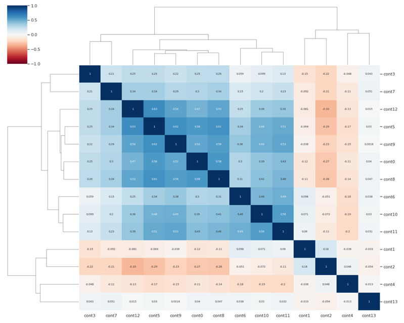

초기에는 cont0~13 변수 각각을 하나의 군집으로 배정한 상태에서 시작하여,

군집 간 결합 조건으로 두 군집에 포함된 변수간의 피어슨 상관도 절대값의 평균이 0.5이상 일 때,

피어슨 상관도의 절대값이 높은 것을 우선으로 군집들을 결합한다. 군집의 크기가 가장 큰 변수들을 구하라.

Hint] cont0 ~ 13간의 거리는 [단계 2-1] corr을 이용하여 군집 결합 조건을 고려하여 구한다.

```
(두 변수간에 피어슨 상관도의 절대값이 높을 수록 거리는 가깝다.)
```

**함수가이드**

sklearn.cluster.AgglomerativeClustering

문제 지시사항 외 Default 값 사용

```python
# 역수를 취하는 접근법은 평균을 구하는 과정에서의 왜곡이 발생하여 성립하지 않습니다.
# df_dist = 1 / df_corr.abs() - 1

# 상관도를 문제에서 제시한 요건에 맞게 거리로 바꿉니다.
# -1, 1에 가까울수록 유사 → 거리가 가까움
# 군집간 거라의 평균을 임계값으로 잡고 있다는 점에서 -abs를 취합니다.
# 자신의 거리는 0이라는 점에서. 1을 더해줍니다.
# 절대값의 평균 0.5 이상일때 → 거리가 0.5 이하일 때

df_dist = 1 - df_corr.abs()
df_dist
```

|  | cont0 | cont1 | cont2 | cont3 | cont4 | cont5 | cont6 | cont7 | cont8 | cont9 | cont10 | cont11 | cont12 | cont13 |
| --- | --- | --- | --- | --- | --- | --- | --- | --- | --- | --- | --- | --- | --- | --- |
| cont0 | 0.000000 | 0.876656 | 0.731379 | 0.744738 | 0.891803 | 0.426106 | 0.698328 | 0.699647 | 0.420382 | 0.475519 | 0.605599 | 0.574650 | 0.526751 | 0.960387 |
| cont1 | 0.876656 | 0.000000 | 0.825375 | 0.846890 | 0.964545 | 0.935703 | 0.900551 | 0.908518 | 0.894189 | 0.964056 | 0.929074 | 0.939123 | 0.919857 | 0.965964 |
| cont2 | 0.731379 | 0.825375 | 0.000000 | 0.783762 | 0.952935 | 0.708268 | 0.949512 | 0.786312 | 0.721504 | 0.772345 | 0.928312 | 0.892125 | 0.670805 | 0.945418 |
| cont3 | 0.744738 | 0.846890 | 0.783762 | 0.000000 | 0.951323 | 0.746408 | 0.940485 | 0.784943 | 0.735283 | 0.779625 | 0.900306 | 0.868033 | 0.746280 | 0.956879 |
| cont4 | 0.891803 | 0.964545 | 0.952935 | 0.951323 | 0.000000 | 0.833840 | 0.824720 | 0.894680 | 0.863171 | 0.849016 | 0.812976 | 0.800440 | 0.872047 | 0.987873 |
| cont5 | 0.426106 | 0.935703 | 0.708268 | 0.746408 | 0.833840 | 0.000000 | 0.658448 | 0.658311 | 0.393671 | 0.384551 | 0.517975 | 0.490684 | 0.368460 | 0.970470 |
| cont6 | 0.698328 | 0.900551 | 0.949512 | 0.940485 | 0.824720 | 0.658448 | 0.000000 | 0.848334 | 0.692956 | 0.618859 | 0.544338 | 0.514565 | 0.753715 | 0.962270 |
| cont7 | 0.699647 | 0.908518 | 0.786312 | 0.784943 | 0.894680 | 0.658311 | 0.848334 | 0.000000 | 0.665321 | 0.716079 | 0.799377 | 0.771370 | 0.662084 | 0.950838 |
| cont8 | 0.420382 | 0.894189 | 0.721504 | 0.735283 | 0.863171 | 0.393671 | 0.692956 | 0.665321 | 0.000000 | 0.441440 | 0.586381 | 0.541911 | 0.469785 | 0.952930 |
| cont9 | 0.475519 | 0.964056 | 0.772345 | 0.779625 | 0.849016 | 0.384551 | 0.618859 | 0.716079 | 0.441440 | 0.000000 | 0.515339 | 0.470748 | 0.461722 | 0.999043 |
| cont10 | 0.605599 | 0.929074 | 0.928312 | 0.900306 | 0.812976 | 0.517975 | 0.544338 | 0.799377 | 0.586381 | 0.515339 | 0.000000 | 0.442839 | 0.638898 | 0.971468 |
| cont11 | 0.574650 | 0.939123 | 0.892125 | 0.868033 | 0.800440 | 0.490684 | 0.514565 | 0.771370 | 0.541911 | 0.470748 | 0.442839 | 0.000000 | 0.614247 | 0.968689 |
| cont12 | 0.526751 | 0.919857 | 0.670805 | 0.746280 | 0.872047 | 0.368460 | 0.753715 | 0.662084 | 0.469785 | 0.461722 | 0.638898 | 0.614247 | 0.000000 | 0.986216 |
| cont13 | 0.960387 | 0.965964 | 0.945418 | 0.956879 | 0.987873 | 0.970470 | 0.962270 | 0.950838 | 0.952930 | 0.999043 | 0.971468 | 0.968689 | 0.986216 | 0.000000 |

```python
'''
`AgglomerativeClustering`은 scikit-learn 라이브러리에서 제공하는 계층적 클러스터링 알고리즘입니다.
이 알고리즘은 데이터 포인트들을 점진적으로 병합하여 계층적 클러스터를 생성합니다.

### `AgglomerativeClustering` 클래스의 인자
class sklearn.cluster.AgglomerativeClustering(
    n_clusters=2,
    *,
    affinity='euclidean',
    memory=None,
    connectivity=None,
    compute_full_tree='auto',
    linkage='ward',
    distance_threshold=None
)

1. n_clusters (int, default=2):
   - 클러스터의 수를 지정합니다. `distance_threshold`가 지정되지 않은 경우에만 사용됩니다.
2. affinity (str or callable, default='euclidean'):
   - 데이터 간의 거리를 계산하는 방식입니다. 사용 가능한 값으로는 'euclidean', 'l1', 'l2', 'manhattan',
       'cosine', 'precomputed' 등이 있습니다. `linkage='ward'`인 경우 'euclidean'만 사용할 수 있습니다.
3. memory (str or object, default=None):
   - 캐시 디렉토리를 지정하거나 joblib.Memory 객체를 사용할 수 있습니다. 디스크 캐시를 통해 계산을 저장할 수 있습니다.
4. connectivity (array-like or callable, default=None):
   - 데이터의 연결을 정의하는 커넥티비티 행렬입니다. 데이터 간의 연결성을 나타냅니다.
5. compute_full_tree ('auto' or bool, default='auto'):
   - True로 설정하면 모든 데이터 포인트에 대해 전체 트리를 계산합니다. 클러스터의 수가 지정되지 않은 경우에만 사용됩니다.
6. linkage (str, default='ward'):
   - 클러스터 병합 기준입니다. 사용 가능한 값으로는 'ward', 'complete', 'average', 'single'이 있습니다.
   - 'ward': 클러스터 내 분산을 최소화합니다.
   - 'complete': 두 클러스터 간 최대 거리 (최대 연결).
   - 'average': 두 클러스터 간 평균 거리 (평균 연결).
   - 'single': 두 클러스터 간 최소 거리 (최소 연결).
7. distance_threshold (float, default=None):
   - 클러스터링을 멈출 거리 임계값입니다. 설정되면 클러스터의 수는 `distance_threshold`에 따라 결정됩니다.

### 리턴값
- labels_ (array, shape [n_samples]):
  - 각 데이터 포인트의 클러스터 레이블을 나타냅니다.

### 속성
- n_clusters_:
  - 최종 클러스터의 수를 나타냅니다. `distance_threshold`가 설정된 경우 사용됩니다.
- labels_:
  - 각 데이터 포인트의 클러스터 레이블을 나타냅니다.
- n_leaves_:
  - 클러스터링의 트리 리프 수를 나타냅니다.
- n_connected_components_:
  - 연결된 구성 요소의 수를 나타냅니다.
- children_:
  - 각 병합 단계에서 병합된 클러스터의 인덱스를 나타내는 배열입니다.

### 메서드
- fit(X[, y]):
  - 모델을 데이터 X에 맞춥니다.
- fit_predict(X[, y]):
  - 모델을 데이터 X에 맞추고, 클러스터 레이블을 반환합니다.
- get_params([deep]):
  - 추정기의 매개변수를 반환합니다.
- set_params(params):
  - 추정기의 매개변수를 설정합니다.

### 사용 예제
아래 예제에서는 AgglomerativeClustering 객체를 생성하고 데이터에 맞춘 후, 클러스터 레이블과 병합된 클러스터 정보를 출력합니다.
`AgglomerativeClustering`은 계층적 클러스터링의 강력한 도구로,
다양한 거리 측정 방법과 병합 기준을 통해 유연하게 클러스터링을 수행할 수 있습니다.
'''

import numpy as np
from sklearn.cluster import AgglomerativeClustering

# 데이터 생성
X = np.array([[1, 2], [1, 4], [1, 0],
              [4, 2], [4, 4], [4, 0]])

# AgglomerativeClustering 객체 생성
clustering = AgglomerativeClustering(n_clusters=2, affinity='euclidean', linkage='ward')

# 데이터에 적합
clustering.fit(X)

# 결과 출력
print("클러스터 레이블:", clustering.labels_)
print("병합된 클러스터:")
print(clustering.children_)
print("리프 수:", clustering.n_leaves_)
print("연결된 구성 요소 수:", clustering.n_connected_components_)
```

```
클러스터 레이블: [1 1 1 0 0 0]
병합된 클러스터:
[[0 1]
 [3 5]
 [2 6]
 [4 7]
 [8 9]]
리프 수: 6
연결된 구성 요소 수: 1
```

```python
from sklearn.cluster import AgglomerativeClustering

clu_agg = AgglomerativeClustering(
    n_clusters = None, # distance_threshold에 의해 결정
    affinity = 'precomputed', # 거리행렬입력 받도록 설정
    linkage = 'average', # 피어슨 상관도 절대값의 평균
    distance_threshold = 0.5 # 0.5이상 일 때→ 이하
)

clu_agg.fit(df_dist)

# 결과 출력
print("클러스터 레이블:", clu_agg.labels_)
print("병합된 클러스터:")
print(clu_agg.children_)
print("리프 수:", clu_agg.n_leaves_)
print("연결된 구성 요소 수:", clu_agg.n_connected_components_)
```

```
클러스터 레이블: [0 5 6 4 7 0 8 2 0 0 1 1 0 3]
병합된 클러스터:
[[ 5 12]
 [ 0  8]
 [ 9 14]
 [10 11]
 [15 16]
 [ 6 17]
 [18 19]
 [ 7 20]
 [ 2  3]
 [21 22]
 [ 4 23]
 [ 1 24]
 [13 25]]
리프 수: 14
연결된 구성 요소 수: 1
```

```python
pd.Series(clu_agg.labels_).value_counts().to_frame().T
```

|  | 0 | 1 | 8 | 7 | 6 | 5 | 4 | 3 | 2 |
| --- | --- | --- | --- | --- | --- | --- | --- | --- | --- |
| 0 | 5 | 2 | 1 | 1 | 1 | 1 | 1 | 1 | 1 |

```python
pd.Series(clu_agg.labels_).value_counts().idxmax()
```

```
0
```

```python
X_corr = df_dist.loc[
    clu_agg.labels_ == pd.Series(clu_agg.labels_).value_counts().idxmax()
].index.tolist()

X_corr
```

```
['cont0', 'cont5', 'cont8', 'cont9', 'cont12']
```

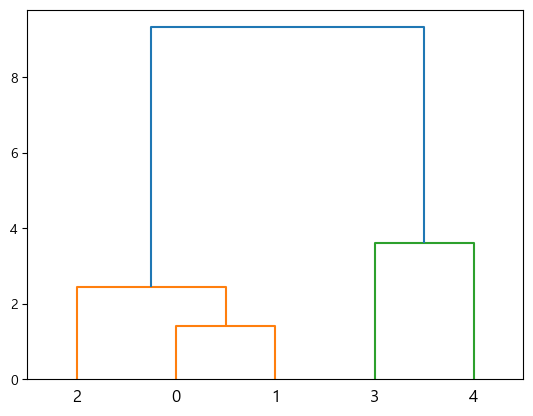

```python
'''
`scipy.cluster.hierarchy.linkage()` 함수는 계층적 클러스터링(Hierarchical Clustering)을 수행하기 위해 사용되는 함수입니다.
이 함수는 데이터 간의 거리를 기반으로 클러스터를 생성하고, 클러스터 간의 계층적 구조를 구축합니다.

### `linkage()` 함수의 설명

#### 1. 함수 정의
from scipy.cluster.hierarchy import linkage

#### 2. 함수 시그니처
scipy.cluster.hierarchy.linkage(y, method='single', metric='euclidean', optimal_ordering=False)

#### 3. 인자
- `y`:
  - 클러스터링할 데이터로, `n x m` 크기의 2차원 배열 또는 `(n * (n-1)) / 2` 크기의 1차원 배열을 입력으로 받습니다.
  - 만약 2차원 배열이라면, 각 행은 하나의 관측치를 나타내며, `linkage()` 함수는 이를 통해 거리 행렬을 계산합니다.
  - 1차원 배열인 경우, 이미 거리 행렬의 상삼각 부분이 계산된 상태(즉, `pdist`와 같은 함수의 결과)로 입력됩니다.
- `method`:
  - 클러스터 간의 거리를 계산하는 방법을 지정합니다.
  - 가능한 값으로는 `'single'`, `'complete'`, `'average'`, `'weighted'`, `'centroid'`, `'median'`, `'ward'` 등이 있습니다.
  - 기본값은 `'single'`이며, 이는 최단 연결법을 사용하여 클러스터 간의 최소 거리를 기준으로 병합합니다.
  주요 클러스터링 방법들:
  - `'single'`: 최단 연결법, 두 클러스터 간의 가장 가까운 점들 사이의 거리를 기준으로 병합.
  - `'complete'`: 최장 연결법, 두 클러스터 간의 가장 먼 점들 사이의 거리를 기준으로 병합.
  - `'average'`: 평균 연결법, 두 클러스터 간의 모든 점들의 평균 거리를 기준으로 병합.
  - `'ward'`: Ward의 최소 분산 방법, 클러스터의 내적 분산의 증가를 최소화하는 방향으로 병합.
- `metric`:
  - 거리를 계산하는 방법을 지정합니다. 기본값은 `'euclidean'`(유클리드 거리)입니다.
  - `metric`에는 `pdist`에서 사용할 수 있는 다양한 거리 계산 방법들이 포함됩니다
      (예: `'cityblock'`, `'cosine'`, `'hamming'`, `'jaccard'`, `'minkowski'` 등).
- `optimal_ordering`:
  - 최적의 클러스터 순서를 찾을지 여부를 지정합니다. 기본값은 `False`입니다.
  - `True`로 설정하면 덴드로그램에서 리프 노드들이 최적화된 순서로 배치되어,
      같은 클러스터에 속하는 항목들이 인접하게 표시됩니다.
  - 이 옵션을 사용하면 덴드로그램의 시각적 해석이 더 명확해질 수 있습니다.

#### 4. 리턴값
- `Z`:
  - `linkage()` 함수는 계층적 클러스터링의 결과를 나타내는 행렬 `Z`를 반환합니다.
  - `Z`는 `(n-1) x 4` 크기의 2차원 배열로, 클러스터 병합의 단계별 정보를 포함하고 있습니다.
      여기서 `n`은 입력 데이터의 샘플 수입니다.

  각 행은 클러스터 병합의 단계를 나타내며, 각 열은 다음 정보를 포함합니다:
  1. 첫 번째 클러스터의 인덱스: 병합된 첫 번째 클러스터의 인덱스.
  2. 두 번째 클러스터의 인덱스: 병합된 두 번째 클러스터의 인덱스.
  3. 병합된 클러스터 사이의 거리: 병합 시 두 클러스터 간의 거리.
  4. 병합된 클러스터의 크기: 병합된 클러스터에 속하는 원소의 수.

  예시:
  Z = linkage(data, method='single')

  반환된 `Z`의 첫 번째 행이 `[3. ,  4. ,  1. ,  2.]`이라면,
  이는 인덱스 3과 4에 해당하는 클러스터가 거리 1에서 병합되었으며, 병합 후 클러스터 크기는 2임을 의미합니다.

#### 5. 속성 및 함수

`linkage()` 함수 자체에는 속성이나 메서드가 따로 존재하지 않지만, 반환된 `Z` 행렬을 이용해 다양한 분석을 수행할 수 있습니다.

- `scipy.cluster.hierarchy.dendrogram()`:
  - `Z` 행렬을 이용해 덴드로그램(계층적 클러스터링의 시각적 표현)을 그릴 수 있습니다.

  예시:
  from scipy.cluster.hierarchy import dendrogram
  import matplotlib.pyplot as plt

  # 덴드로그램 그리기
  dendrogram(Z)
  plt.show()

- `scipy.cluster.hierarchy.fcluster()`:
  - `Z` 행렬을 기반으로 클러스터를 형성하는 데 사용됩니다. 주어진 임계값을 넘는 클러스터들로 데이터를 나눌 수 있습니다.

  예시:
  from scipy.cluster.hierarchy import fcluster

  # 클러스터 형성
  clusters = fcluster(Z, t=1.5, criterion='distance')

### 요약
- `scipy.cluster.hierarchy.linkage()` 함수는 계층적 클러스터링을 수행하여 데이터 간의 계층적 구조를 표현하는 함수입니다.
- 다양한 방법(method)과 거리(metric)를 통해 클러스터링을 수행할 수 있으며, 결과로 계층적 병합 정보가 담긴 행렬 `Z`를 반환합니다.
- 반환된 `Z`를 이용해 덴드로그램을 그리거나, 클러스터를 형성할 수 있습니다.
'''

import numpy as np
from scipy.cluster.hierarchy import linkage, dendrogram
import matplotlib.pyplot as plt

# 예제 데이터 생성
data = np.array([[1, 2], [2, 3], [3, 4], [5, 6], [8, 8]])

# 계층적 클러스터링 수행
Z = linkage(data, method='ward')

# 덴드로그램 시각화
dendrogram(Z)
plt.show()
```

```
Z =
[[ 5.         12.          0.36845954  2.        ]
 [ 0.          8.          0.42038217  2.        ]
 [ 9.         14.          0.42313695  3.        ]
 [10.         11.          0.44283934  2.        ]
 [15.         16.          0.45554535  5.        ]
 [ 6.         17.          0.52945163  3.        ]
 [18.         19.          0.59858252  8.        ]
 [ 7.         20.          0.72756524  9.        ]
 [ 2.          3.          0.78376232  2.        ]
 [21.         22.          0.80037013 11.        ]
 [ 4.         23.          0.86790466 12.        ]
 [ 1.         24.          0.90871139 13.        ]
 [13.         25.          0.96757262 14.        ]]
-------------------------------------------------------------------------------------------
```

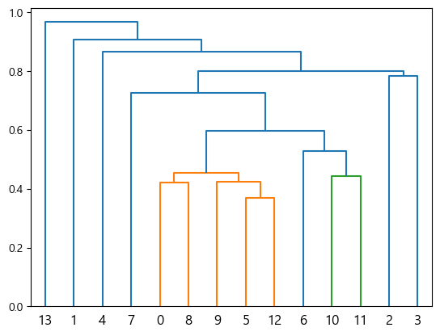

```python
# 속성에 대한 연관성으로 사용하고 있는 방법입니다.
# scipy에 있는 cluster 모듈로 구현해보고
# 속성간에 연관성을 시각화 해봅니다.
from scipy.cluster import hierarchy
from scipy.spatial.distance import squareform

df_corr = df_basetable[['cont{}'.format(i) for i in range(14)]].corr()
df_dist = 1 - df_corr.abs()

# scipy.cluster hierarchy를 통해 군집화를 합니다.
Z = hierarchy.linkage(squareform(df_dist), method='average')
print('Z = ')
print(Z)
print('-------------------------------------------------------------------------------------------')

plt.figure()
# 군집 결합 입계점을 0.5로 하여 색상으로 군집들을 표시합니다.
hierarchy.dendrogram(Z, color_threshold=0.5)
plt.show()
```

```python
# 단계 2-2까지 정리

'''
코드는 연속형 변수들 간의 상관계수를 이용하여 군집화를 수행하고, 가장 큰 군집의 변수들을 식별한 후, 이를 시각화합니다.

### 1. 상관계수 계산 및 거리 행렬 생성
df_corr = df_basetable[cont_cols].corr()
- `df_basetable` 데이터프레임에서 연속형 변수(`cont_cols`)들 간의 상관계수 행렬을 계산합니다.

df_dist = 1 - df_corr.abs()
- 상관계수의 절대값을 이용하여 거리 행렬을 생성합니다.
    상관계수가 높을수록 거리가 짧아지며, 상관계수가 낮을수록 거리가 길어집니다.

### 2. 병합 군집화 (Agglomerative Clustering) 수행
- `AgglomerativeClustering`을 사용하여 병합 군집화를 수행합니다.
  - `n_clusters=None`:
      클러스터의 수는 `distance_threshold`에 의해 결정됩니다.
  - `affinity='precomputed'`:
      거리 행렬을 직접 입력받도록 설정합니다.
  - `linkage='average'`:
      평균 연결법을 사용하여 클러스터 간 거리를 계산합니다.
  - `distance_threshold=0.5`:
      이 값 이하에서 클러스터를 형성합니다.

### 3. 각 클러스터의 크기 확인
pd.Series(clu_agg.labels_).value_counts().to_frame().T
- 각 클러스터에 속한 변수의 개수를 확인합니다.
- 클러스터 레이블을 시리즈로 변환하고, 각 클러스터의 빈도수를 계산하여 데이터프레임 형식으로 출력합니다.

### 4. 가장 큰 클러스터의 변수들 식별
X_corr = df_dist.loc[
    clu_agg.labels_ == pd.Series(clu_agg.labels_).value_counts().idxmax()
].index.tolist()
- 가장 큰 클러스터의 레이블을 식별하고, 그 클러스터에 속한 변수들의 목록을 추출합니다.
- `clu_agg.labels_`와 가장 큰 클러스터의 레이블이 일치하는 변수들의 인덱스를 리스트로 변환합니다.

### 5. 덴드로그램을 통한 군집 시각화
df_corr = df_basetable[['cont{}'.format(i) for i in range(14)]].corr()
df_dist = 1 - df_corr.abs()
- 상관계수 행렬을 다시 계산하고 거리 행렬을 생성합니다.

Z = hierarchy.linkage(squareform(df_dist), method='average')
- `scipy.cluster.hierarchy`를 사용하여 평균 연결법을 통해 거리 행렬을 기반으로 군집화를 수행합니다.
- `squareform`을 사용하여 거리 행렬을 계층적 군집화 함수가 사용할 수 있는 형태로 변환합니다.

plt.figure()
hierarchy.dendrogram(Z, color_threshold=0.5)
plt.show()
- 덴드로그램을 생성하여 군집 구조를 시각화합니다.
- `color_threshold=0.5`를 설정하여 특정 거리 임계값에서 클러스터를 색상으로 표시합니다.

### 코드의 전체 목표

- 연속형 변수들 간의 상관관계를 이용하여 군집화를 수행합니다.
- 병합 군집화를 통해 변수들을 클러스터로 그룹화하고, 가장 큰 클러스터에 속한 변수들을 식별합니다.
- 덴드로그램을 통해 군집화 결과를 시각화하여 변수 간의 관계를 시각적으로 이해할 수 있도록 합니다.

이 과정은 변수 간의 상관성을 기반으로 변수들을 그룹화하여, 데이터의 구조적 관계를 파악하는 데 도움을 줍니다.
'''
print('')
```

## 단계 2-3

basetable에서 cat0 ~ 9을 각 변수의 첫 번째 범주(알파벳 순)를 제외하고

원핫 인코딩(One-hot encoding)하여 prob2를 만든다.

```python
# 방법 1.
df_prob2 = pd.get_dummies(df_basetable, columns=cat_cols, drop_first=True)

df_prob2.head()
```

| id | cont0 | cont1 | cont2 | cont3 | cont4 | cont5 | cont6 | cont7 | cont8 | cont9 | ... | cat9_F | cat9_G | cat9_H | cat9_I | cat9_J | cat9_K | cat9_L | cat9_M | cat9_N | cat9_O |
| --- | --- | --- | --- | --- | --- | --- | --- | --- | --- | --- | --- | --- | --- | --- | --- | --- | --- | --- | --- | --- | --- |
| 267387 | 0.65226 | 0.55771 | 0.25398 | 0.28196 | 0.82400 | 0.22443 | 0.69220 | 0.30912 | 0.47134 | 0.53290 | ... | 0 | 1 | 0 | 0 | 0 | 0 | 0 | 0 | 0 | 0 |
| 410037 | 0.36970 | 0.68159 | 0.30038 | 0.20156 | 0.46113 | 0.43278 | 0.97199 | 0.62596 | 0.40193 | 0.49181 | ... | 1 | 0 | 0 | 0 | 0 | 0 | 0 | 0 | 0 | 0 |
| 139373 | 0.47881 | 0.63976 | 0.40024 | 0.24153 | 0.27128 | 0.36238 | 0.41310 | 0.27010 | 0.40112 | 0.53052 | ... | 0 | 0 | 0 | 0 | 1 | 0 | 0 | 0 | 0 | 0 |
| 113765 | 0.43438 | 0.77575 | 0.54887 | 0.21935 | 0.27944 | 0.32670 | 0.42301 | 0.28331 | 0.46425 | 0.38302 | ... | 0 | 1 | 0 | 0 | 0 | 0 | 0 | 0 | 0 | 0 |
| 179915 | 0.47866 | 0.64326 | 0.37255 | 0.21004 | 0.41188 | 0.20121 | 0.37466 | 0.46316 | 0.75578 | 0.55676 | ... | 0 | 0 | 0 | 0 | 0 | 0 | 1 | 0 | 0 | 0 |

5 rows × 45 columns

```python
df_prob2.columns
```

```
Index(['cont0', 'cont1', 'cont2', 'cont3', 'cont4', 'cont5', 'cont6', 'cont7',
       'cont8', 'cont9', 'cont10', 'cont11', 'cont12', 'cont13', 'target',
       'targetA', 'cat0_B', 'cat1_B', 'cat2_B', 'cat3_C', 'cat3_D', 'cat4_C',
       'cat5_B', 'cat5_C', 'cat5_D', 'cat6_B', 'cat6_C', 'cat7_D', 'cat7_E',
       'cat7_G', 'cat8_C', 'cat8_D', 'cat8_E', 'cat8_G', 'cat9_B', 'cat9_F',
       'cat9_G', 'cat9_H', 'cat9_I', 'cat9_J', 'cat9_K', 'cat9_L', 'cat9_M',
       'cat9_N', 'cat9_O'],
      dtype='object')
```

```python
'''
`OneHotEncoder`는 `sklearn.preprocessing` 모듈에 포함된 클래스입니다.
이 클래스는 범주형 데이터를 숫자 형태의 원-핫 인코딩(One-Hot Encoding)으로 변환하는 데 사용됩니다.
원-핫 인코딩은 범주형 변수를 이진 벡터로 변환하여, 머신러닝 모델에 적합한 입력 데이터로 만듭니다.

### `OneHotEncoder` 클래스의 설명
#### 1. 클래스 정의
from sklearn.preprocessing import OneHotEncoder

#### 2. 생성자 시그니처
OneHotEncoder(*, categories='auto', drop=None, sparse_output=True, dtype=<class 'numpy.float64'>,
                handle_unknown='error', min_frequency=None, max_categories=None, feature_name_combiner='concat')

#### 3. 주요 인자
- `categories`:
  - 각 특성(feature)에 대해 인코딩할 범주를 지정합니다.
  - 기본값은 `'auto'`로, 자동으로 데이터를 학습하여 범주를 결정합니다.
  - 사용자가 명시적으로 범주의 리스트를 제공할 수도 있습니다.
    예시:
  categories=[['A', 'B', 'C'], [1, 2, 3]]

- `drop`:
  - 일부 범주를 드롭하여 다중공선성을 줄일 수 있습니다.
  - `'first'`: 첫 번째 범주를 드롭.
  - `'if_binary'`: 이진 범주형 변수의 경우 첫 번째 범주를 드롭.
  - `'none'` (기본값): 범주를 드롭하지 않음.
  - 사용자가 명시적으로 드롭할 범주의 리스트를 제공할 수도 있습니다.

- `sparse_output`:
  - `True`로 설정하면 희소 행렬(sparse matrix) 형태로 결과를 반환합니다. 기본값은 `True`입니다.
  - `False`로 설정하면 밀집 행렬(dense matrix)로 결과를 반환합니다.

- `dtype`:
  - 인코딩된 결과의 데이터 타입을 지정합니다.
  - 기본값은 `numpy.float64`입니다.

- `handle_unknown`:
  - 인코딩 시 학습되지 않은 범주를 어떻게 처리할지 지정합니다.
  - `'error'` (기본값): 알 수 없는 범주가 나타나면 오류를 발생시킵니다.
  - `'ignore'`: 알 수 없는 범주를 무시하고, 해당 범주의 원-핫 인코딩은 모두 0으로 처리합니다.

- `min_frequency` 및 `max_categories` (버전 1.2부터 추가):
  - `min_frequency`: 최소 빈도를 설정해 이보다 작은 빈도의 범주는 드롭할 수 있습니다.
  - `max_categories`: 최대 범주 수를 설정해 이보다 많은 범주를 가진 경우 일부를 드롭할 수 있습니다.

- `feature_name_combiner` (버전 1.3부터 추가):
  - 기본값은 `'concat'`으로, 원-핫 인코딩된 피처의 이름을 결합하여 형성합니다.

#### 4. 리턴값
- `fit_transform` 또는 `transform` 메서드를 사용하면 원-핫 인코딩된 결과를 반환합니다.
- 이 결과는 기본적으로 희소 행렬(`scipy.sparse.csr_matrix`) 형태이며,
    `sparse_output=False`로 설정하면 밀집 행렬(`numpy.ndarray`)로 반환됩니다.

#### 5. 주요 속성
- `categories_`:
  - 인코더가 학습한 범주들의 리스트입니다.
  - 각 입력 변수에 대한 범주의 목록을 포함하는 리스트가 반환됩니다.

  예시:
  encoder.categories_

- `drop_idx_`:
  - 드롭된 범주의 인덱스를 나타냅니다.
  - `drop` 옵션이 설정된 경우에만 이 속성이 유효합니다.

#### 6. 주요 메서드
- `fit(X[, y])`:
  - `X`를 학습하여 인코딩할 범주를 결정합니다.
  - `X`는 2차원 배열, 데이터프레임 또는 리스트의 리스트 형태로 제공됩니다.

- `fit_transform(X[, y])`:
  - `fit`을 수행한 후, `X`를 변환하여 원-핫 인코딩된 결과를 반환합니다.
  - `fit`과 `transform`을 연달아 수행할 때 사용됩니다.

- `transform(X)`:
  - 학습된 범주에 따라 `X`를 원-핫 인코딩된 결과로 변환합니다.
  - `X`는 `fit`과 동일한 형태의 데이터여야 합니다.

- `inverse_transform(X)`:
  - 원-핫 인코딩된 데이터 `X`를 원래 범주형 데이터로 변환합니다.
  - 인코딩 이전의 데이터로 복원하는 데 사용됩니다.

- `get_feature_names_out([input_features])`:
  - 원-핫 인코딩된 피처들의 이름을 반환합니다.
  - `input_features`는 원본 피처 이름의 리스트로, 이를 이용해 새로운 피처 이름을 생성할 수 있습니다.

  예시:
  encoder.get_feature_names_out(['feature1', 'feature2'])
'''

import numpy as np
from sklearn.preprocessing import OneHotEncoder

# 예제 데이터
data = np.array([['Male', 1], ['Female', 3], ['Female', 2]])

# OneHotEncoder 인스턴스 생성 (sparse_output -> sparse)
encoder = OneHotEncoder(sparse=False)  # sparse_output을 sparse로 변경

# 데이터 학습 및 변환
encoded_data = encoder.fit_transform(data)

# 결과 출력
print(encoded_data)
print(encoder.categories_)

# get_feature_names로 피처 이름 출력
print(encoder.get_feature_names(['gender', 'category']))

# print(encoder.get_feature_names_out(['gender', 'category']))
```

```
[[0. 1. 1. 0. 0.]
 [1. 0. 0. 0. 1.]
 [1. 0. 0. 1. 0.]]
[array(['Female', 'Male'], dtype='<U6'), array(['1', '2', '3'], dtype='<U6')]
['gender_Female' 'gender_Male' 'category_1' 'category_2' 'category_3']
```

```python
df_basetable[cat_cols]
```

| id | cat0 | cat1 | cat2 | cat3 | cat4 | cat5 | cat6 | cat7 | cat8 | cat9 |
| --- | --- | --- | --- | --- | --- | --- | --- | --- | --- | --- |
| 267387 | A | B | B | C | B | B | A | E | G | G |
| 410037 | A | A | A | A | B | B | A | E | C | F |
| 139373 | A | A | B | A | B | B | A | E | C | J |
| 113765 | A | A | A | C | B | B | A | E | C | G |
| 179915 | A | B | A | C | B | B | A | E | E | L |
| ... | ... | ... | ... | ... | ... | ... | ... | ... | ... | ... |
| 320975 | A | A | A | C | B | B | A | E | C | I |
| 29591 | A | B | A | C | B | B | A | E | C | F |
| 46717 | A | B | B | C | B | D | A | E | G | F |
| 463191 | A | A | A | C | B | D | A | E | E | F |
| 415856 | A | A | A | C | B | D | A | E | G | I |

240000 rows × 10 columns

```python
'''
df_basetable[cat_cols].apply(lambda x: print(x), axis=0)

[결과]
id
267387    A
410037    A
139373    A
113765    A
179915    A
         ..
320975    A
29591     A
46717     A
463191    A
415856    A
Name: cat0, Length: 240000, dtype: object
id
267387    B
410037    A
139373    A
113765    A
179915    B
         ..
320975    A
29591     B
46717     B
463191    A
415856    A
Name: cat1, Length: 240000, dtype: object
id
267387    B
410037    A
139373    B
113765    A
179915    A
         ..
320975    A
29591     A
46717     B
463191    A
415856    A
Name: cat2, Length: 240000, dtype: object
id
267387    C
410037    A
139373    A
113765    C
179915    C
         ..
320975    C
29591     C
46717     C
463191    C
415856    C
Name: cat3, Length: 240000, dtype: object
id
267387    B
410037    B
139373    B
113765    B
179915    B
         ..
320975    B
29591     B
46717     B
463191    B
415856    B
Name: cat4, Length: 240000, dtype: object
id
267387    B
410037    B
139373    B
113765    B
179915    B
         ..
320975    B
29591     B
46717     D
463191    D
415856    D
Name: cat5, Length: 240000, dtype: object
id
267387    A
410037    A
139373    A
113765    A
179915    A
         ..
320975    A
29591     A
46717     A
463191    A
415856    A
Name: cat6, Length: 240000, dtype: object
id
267387    E
410037    E
139373    E
113765    E
179915    E
         ..
320975    E
29591     E
46717     E
463191    E
415856    E
Name: cat7, Length: 240000, dtype: object
id
267387    G
410037    C
139373    C
113765    C
179915    E
         ..
320975    C
29591     C
46717     G
463191    E
415856    G
Name: cat8, Length: 240000, dtype: object
id
267387    G
410037    F
139373    J
113765    G
179915    L
         ..
320975    I
29591     F
46717     F
463191    F
415856    I
Name: cat9, Length: 240000, dtype: object
cat0    None
cat1    None
cat2    None
cat3    None
cat4    None
cat5    None
cat6    None
cat7    None
cat8    None
cat9    None
dtype: object
'''
print('')
```

```python
# 방법 2.

from sklearn.preprocessing import OneHotEncoder

# drop 매개변수를 통해 제외할 가변수화에서 제외한 수준을 지정할 수 있습니다.
ohe = OneHotEncoder(
    # 사전순으로 첫번째 범주값을 제외합니다.
    drop=df_basetable[cat_cols].apply(lambda x: np.sort(x.unique())[0], axis=0),
    sparse=False, # pd.DataFrame에 넣을 수 있도록, Dense Matrix로 받습니다.
    dtype=np.int64
)

ohe.fit(df_basetable[cat_cols])
```

```
OneHotEncoder(categorical_features=None, categories=None,
              drop=array(['A', 'A', 'A', 'A', 'B', 'A', 'A', 'B', 'A', 'A'], dtype=object),
              dtype=<class 'numpy.int64'>, handle_unknown='error',
              n_values=None, sparse=False)
```

```python
# 변수명을 만들어 냅니다.
dum_cols = ohe.get_feature_names(cat_cols)

print('dum_cols = ', dum_cols)
print('------------------------------------------------------------------------------')
print('cat_cols = ', cat_cols)
print('------------------------------------------------------------------------------')
print('df_basetable.columns = ', df_basetable.columns)
print('------------------------------------------------------------------------------')

df_prob2 = pd.concat([
    df_basetable.drop(columns=cat_cols),
    pd.DataFrame(ohe.transform(df_basetable[cat_cols]),
    index=df_basetable.index, columns=dum_cols)
], axis=1)

print('df_prob2.columns = ', df_prob2.columns)
print('------------------------------------------------------------------------------')
```

```
dum_cols =  ['cat0_B' 'cat1_B' 'cat2_B' 'cat3_C' 'cat3_D' 'cat4_C' 'cat5_B' 'cat5_C'
 'cat5_D' 'cat6_B' 'cat6_C' 'cat7_D' 'cat7_E' 'cat7_G' 'cat8_C' 'cat8_D'
 'cat8_E' 'cat8_G' 'cat9_B' 'cat9_F' 'cat9_G' 'cat9_H' 'cat9_I' 'cat9_J'
 'cat9_K' 'cat9_L' 'cat9_M' 'cat9_N' 'cat9_O']
------------------------------------------------------------------------------
cat_cols =  ['cat0', 'cat1', 'cat2', 'cat3', 'cat4', 'cat5', 'cat6', 'cat7', 'cat8', 'cat9']
------------------------------------------------------------------------------
df_basetable.columns =  Index(['cat0', 'cat1', 'cat2', 'cat3', 'cat4', 'cat5', 'cat6', 'cat7', 'cat8',
       'cat9', 'cont0', 'cont1', 'cont2', 'cont3', 'cont4', 'cont5', 'cont6',
       'cont7', 'cont8', 'cont9', 'cont10', 'cont11', 'cont12', 'cont13',
       'target', 'targetA'],
      dtype='object')
------------------------------------------------------------------------------
df_prob2.columns =  Index(['cont0', 'cont1', 'cont2', 'cont3', 'cont4', 'cont5', 'cont6', 'cont7',
       'cont8', 'cont9', 'cont10', 'cont11', 'cont12', 'cont13', 'target',
       'targetA', 'cat0_B', 'cat1_B', 'cat2_B', 'cat3_C', 'cat3_D', 'cat4_C',
       'cat5_B', 'cat5_C', 'cat5_D', 'cat6_B', 'cat6_C', 'cat7_D', 'cat7_E',
       'cat7_G', 'cat8_C', 'cat8_D', 'cat8_E', 'cat8_G', 'cat9_B', 'cat9_F',
       'cat9_G', 'cat9_H', 'cat9_I', 'cat9_J', 'cat9_K', 'cat9_L', 'cat9_M',
       'cat9_N', 'cat9_O'],
      dtype='object')
------------------------------------------------------------------------------
```

```python
# 단계 2-3 설명

'''
코드는 범주형 변수를 원-핫 인코딩(One-Hot Encoding)을 통해 더미 변수로 변환하여
모델링에 사용할 수 있는 형태로 만드는 과정입니다.
구체적으로, `pd.get_dummies`와 `OneHotEncoder`를 사용하여 범주형 변수를 처리하고,
결과를 기존 데이터프레임에 결합하는 것을 포함합니다.

### 1. `pd.get_dummies`를 이용한 원-핫 인코딩
- `pd.get_dummies`를 사용하여 `df_basetable`의 범주형 변수(`cat_cols`)들을 원-핫 인코딩합니다.
- `drop_first=True`를 설정하여 각 범주형 변수의 첫 번째 수준을 제외합니다.
    이는 다중공선성을 피하기 위해 사용됩니다.
- 결과는 원-핫 인코딩된 데이터프레임 `df_prob2`입니다.

### 2. `OneHotEncoder` 설정 및 학습
- `OneHotEncoder` 객체를 생성합니다.
  - `drop` 매개변수: 각 범주형 변수의 사전순 첫 번째 범주값을 제외합니다.
      `np.sort(x.unique())[0]`를 사용하여 각 범주형 변수의 고유값을 정렬하고 첫 번째 값을 선택합니다.
  - `sparse=False`: 희소 행렬이 아닌 밀집 행렬로 출력합니다. 이는 `pd.DataFrame`으로 변환할 때 유용합니다.
  - `dtype=np.int64`: 결과 데이터의 타입을 `int64`로 설정합니다.
- `ohe.fit`을 사용하여 `df_basetable[cat_cols]`의 범주형 변수들에 대해 `OneHotEncoder`를 학습시킵니다.

### 3. 원-핫 인코딩된 컬럼 이름 추출
- `OneHotEncoder` 객체에서 원-핫 인코딩된 컬럼 이름을 추출합니다.
    이는 나중에 새로운 데이터프레임을 생성할 때 사용됩니다.

### 4. 데이터 변환 및 결합
- `df_basetable`에서 원래의 범주형 변수(`cat_cols`)들을 드롭합니다.
- `ohe.transform`을 사용하여 `df_basetable[cat_cols]`의 범주형 변수들을 원-핫 인코딩합니다.
- `pd.DataFrame`을 사용하여 원-핫 인코딩된 결과를 데이터프레임으로 변환하고,
    `dum_cols`를 컬럼 이름으로 사용합니다.
- `pd.concat`을 사용하여 원래의 데이터프레임(`df_basetable`에서 범주형 변수를 드롭한 것)과
    원-핫 인코딩된 데이터프레임을 결합합니다. 결합은 열 방향(`axis=1`)으로 수행됩니다.

### 코드의 전체 목표
코드는 범주형 변수를 원-핫 인코딩하여 모델링에 사용할 수 있도록 변환하는 것입니다.
원-핫 인코딩은 범주형 데이터를 수치형 데이터로 변환하여 머신러닝 모델에서 사용할 수 있도록 합니다.
여기서는 두 가지 방법(`pd.get_dummies`와 `OneHotEncoder`)을 사용하여 원-핫 인코딩을 수행하였으며,
각 방법은 다중공선성을 피하기 위해 첫 번째 범주값을 드롭하는 방법을 사용했습니다.
결과적으로, 범주형 변수들이 수치형 더미 변수로 변환되어 기존의 데이터프레임과 결합됩니다.
'''
print('')
```